# Probability Distributions

Shenghao Wu

March 25, 2020

## The Geometric Probability Distribution & Weak Law of Large Numbers

Let us roll a $K$ sided die with numbers $1$, . . . , $K$ written on them where $K > 1$. Each number is equally likely to be rolled. Let $X$ be a random variable representing the number of rolls needed to get the number $K$ for the first time. (Note: number of rolls includes the roll where $K$ appears.)

1. On any roll, what is the probability of rolling the value $K$?

```r
# 1/k
```

2. What are all of the possible values of $X$? 1<=$x$<+∞
3. Create a function with arguments, `K` and `n_sims`, with `n_sims` representing the number of times we should play out this scenario. Your function should return the number of times the die was rolled in order to get the value `K`. (Helpful hint: Try using a while loop)

```r
# Through function we can get how many times we need to get k
nfact <- function(k){
  x<-0
  t<-0
  while(x!=k)
  {
  x<-sample(x = 1:k, size = 1, replace = FALSE)
  t<-t+1
  }
  return(t)
}
# Then through nfact2 we can get how many times we need to get the value k
nfact2 <- function(k,n_sims){

  nfact <- function(k){
  x<-0
  t<-0
  while(x!=k)
  {
  x<-sample(x = 1:k, size = 1, replace = FALSE)
  t<-t+1
  }
  return(t)

}
  q<-replicate(n_sims,nfact(k))
  return(q)
}
nfact2(12,5)
```

```
## [1]  1 12  2 10  9
```

4. For $K = [2, 6, 12, 15]$ simulate 100 rounds of the scenario and plot each set of results with a bar graph.

```r
#k=2,6,12,15  k_sim=100
nfact2(2,100)
```

```
##   [1] 1 1 1 2 2 1 1 1 1 1 1 5 1 2 2 3 3 5 2 1 4 1 1 1 2 1 2 1 1 1 2 2 7 2 1 1 3
##  [38] 3 1 4 1 1 3 2 3 1 2 3 2 2 3 1 2 3 4 1 1 1 1 2 1 2 6 2 2 2 1 2 4 1 2 1 2 1
##  [75] 2 3 1 2 1 2 4 2 3 1 7 2 2 4 1 1 1 2 1 3 1 2 1 1 3 4
```

```r
nfact2(6,100)
```

```
##   [1] 15  1  2  6  4  9  7  2  1 17  3  1  5  7  9  8  2  2  1 18 10  1  1  2  1
##  [26]  6  1  1  3 11  2  2  6  3  3 11  1  1 14  3  6 30  9  1  9  2  7  2  7  6
##  [51]  2  6 14  4  4  3  4  3  3  3  1 16  2  4  5  5  9 12  1  2 13  1  2  3 16
##  [76]  3  2  3  2  1  3  7  8  5  2  1  3  7  1  4  7  6  8  2  4  5  4  7  2  5
```

```r
nfact2(12,100)
```

```
##   [1]   3  10  19   7   5  10  18  12  14   3  16  19  15   4   7   3 100   6
##  [19]   7   5   1   3  10  30  20  19  21  14   3   1  11   1   4   1   2  65
##  [37]  15  13   5  23   2  13  14   2  10   4  20   2   8   8  20   4   1  26
##  [55]  17  16   2   9  21  16  29   9   8  18   1  13  11  15   3  12  12  14
##  [73]   5  56   2  13   3  10   2   6   5  17   3   8   9  22  38   1  14   4
##  [91]   5  18   6  10  69   6  13   8   8   9
```

```r
nfact2(15,100)
```

```
##   [1] 23 13  1 62 22  5  9  9 11  1  7  2 11 24 20  8  3 22  9 21 19 14 41  5  4
##  [26] 21 11 12 12  1  8 13  5 14 46  1  3 15  9  6  2  2 26 11 18  3  2  1 43 28
##  [51] 48  6  4 13 15  3  8  7  6 15  2  8 12  9  2  9  9 28  9 18 17 20  7 25 36
##  [76]  8 12  2  4  7 15 16 12  2  8  6  7  2 10 17 10 23 18 16  5 14 16 34 24 12
```

```r
table(nfact2(15,100))
```

```
##
##  1  2  3  4  5  6  7  8  9 10 11 12 13 14 15 16 17 18 19 20 21 23 24 25 26 28
##  7  8  6  6  7  9  6  2  3  2  5  4  2  2  1  1  3  3  1  2  2  1  1  3  1  2
## 34 38 39 45 65 67 68 77
##  1  1  2  2  1  1  1  1
```

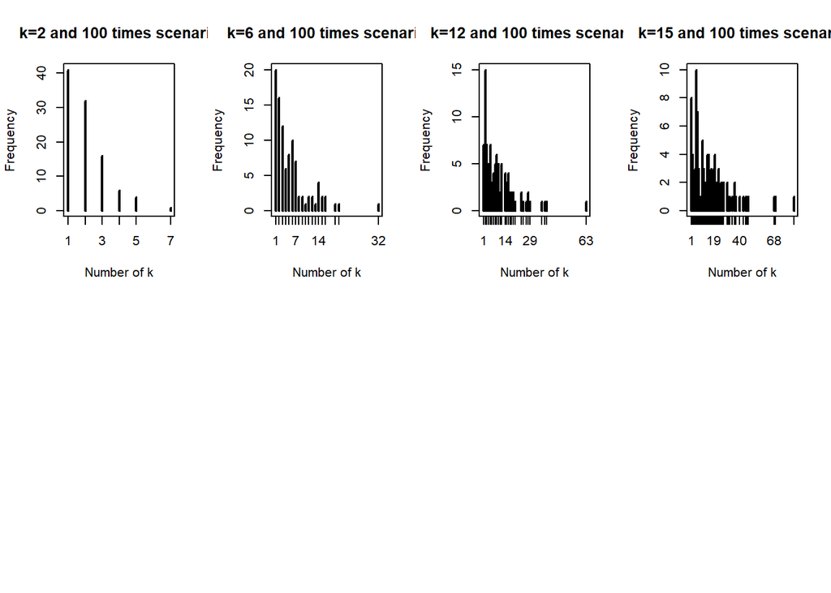

```r
par(mfrow=c(2,4))
plot(table(nfact2(2,100)),xlab = 'Number of k', ylab = 'Frequency', main = 'k=2 and 100 times scenario')
plot(table(nfact2(6,100)),xlab = 'Number of k', ylab = 'Frequency', main = 'k=6 and 100 times scenario')
plot(table(nfact2(12,100)),xlab = 'Number of k', ylab = 'Frequency', main = 'k=12 and 100 times scenario')
plot(table(nfact2(15,100)),xlab = 'Number of k', ylab = 'Frequency', main = 'k=15 and 100 times scenario')
```

5. Repeat question 4 by simulating 100 new rounds of each scenario and plot the results. Have your results changed? Please explain how they have changed. Why might your results be different?

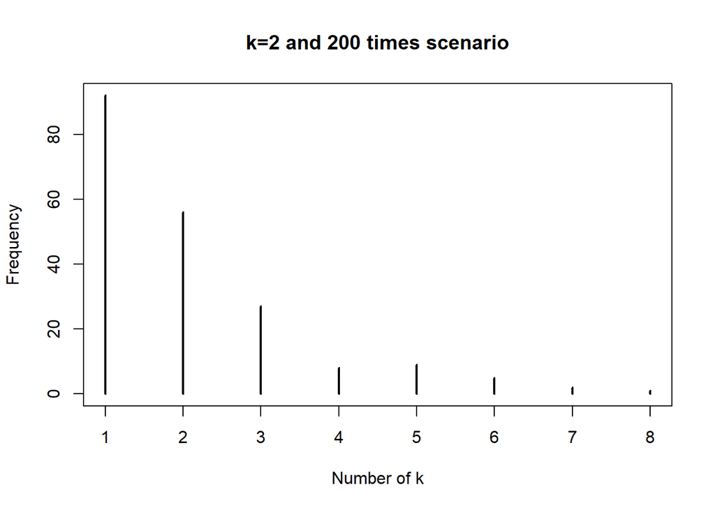

```r
# Here are some difference, if we have more trails, the graph is more similiar to a ladder
plot(table(nfact2(2,200)),xlab = 'Number of k', ylab = 'Frequency', main = 'k=2 and 200 times scenario')
```